# Part 5 Association Rule Learning

`header=FALSE` means that there is no title in the dataset.

```r
dataset = read.csv('Market_Basket_Optimisation.csv', header = FALSE)
head(dataset)
```

|  | V1 | V2 | V3 | V4 | V5 | V6 | V7 | V8 | V9 | V10 | V11 | V12 | V13 | V14 | V15 | V16 | V17 | V18 | V19 | V20 |
| --- | --- | --- | --- | --- | --- | --- | --- | --- | --- | --- | --- | --- | --- | --- | --- | --- | --- | --- | --- | --- |
| 1 | shrimp | almonds | avocado | vegetables mix | green grapes | whole weat flour | yams | cottage cheese | energy drink | tomato juice | low fat yogurt | green tea | honey | salad | mineral water | salmon | antioxydant juice | frozen smoothie | spinach | olive oil |
| 2 | burgers | meatballs | eggs |  |  |  |  |  |  |  |  |  |  |  |  |  |  |  |  |  |
| 3 | chutney |  |  |  |  |  |  |  |  |  |  |  |  |  |  |  |  |  |  |  |
| 4 | turkey | avocado |  |  |  |  |  |  |  |  |  |  |  |  |  |  |  |  |  |  |
| 5 | mineral water | milk | energy bar | whole wheat rice | green tea |  |  |  |  |  |  |  |  |  |  |  |  |  |  |  |
| 6 | low fat yogurt |  |  |  |  |  |  |  |  |  |  |  |  |  |  |  |  |  |  |  |

## 5.1 Apriori

### 5.1.1 Apriori Intuition

Apriori algorithm is about people who bought A also bought B. This algorithm contains three parts and we take market basket optimization as an example.

**Support**:

$$\text{support}(l)=\frac{\text{the number of transactions containing }l}{\text{the number of transactions}}$$

**confidence**:

$$\text{confidence}(l_1\rightarrow l_2)=\frac{\text{the number of transactions containing }l_1\text{ and }l_2}{\text{the number of transactions containing }l_1}$$

**lift**:

$$\text{lift}(l_1\rightarrow l_2)=\frac{\text{confidence}(l_1\rightarrow l_2)}{\text{support}(l_2)}$$

Overall, the step-by-step process of Apriori algorithm is:

- **STEP 1**: Set a minimum support and confidence.
- **STEP 2**: Take all the subsets in transactions having higher support than minimum support.
- **STEP 3**: Take all the rules of these subsets having higher confidence than minimum confidence.
- **STEP 4**: Sort the rules by decreasing lift.

### 5.1.2 Apriori in R

In `R`, we need to convert the dataset into a sparse matrix in order to be fitted in Apriori algorithm model.

```r
# Converting the dataset into a sparse matrix
library(arules)
dataset = read.transactions('Market_Basket_Optimisation.csv', sep = ',', rm.duplicates = TRUE)
```

```
distribution of transactions with duplicates:
1
5
```

```r
summary(dataset)
```

```
transactions as itemMatrix in sparse format with
 7501 rows (elements/itemsets/transactions) and
 119 columns (items) and a density of 0.03288973

most frequent items:
mineral water          eggs     spaghetti  french fries     chocolate       (Other)
         1788          1348          1306          1282          1229         22405

element (itemset/transaction) length distribution:
sizes
   1    2    3    4    5    6    7    8    9   10   11   12   13   14   15   16   18   19
1754 1358 1044  816  667  493  391  324  259  139  102   67   40   22   17    4    1    2
  20
   1

   Min. 1st Qu.  Median    Mean 3rd Qu.    Max.
  1.000   2.000   3.000   3.914   5.000  20.000

includes extended item information - examples:
```

|  | labels |
| --- | --- |
| 1 | almonds |
| 2 | antioxydant juice |
| 3 | asparagus |

This information above shows that:

- There are $5$ transactions containing $1$ duplicate.
- There are $7501$ transactions with $119$ products in total. There are the proportion of $0.03$ containing non-zero values.
- The most frequent item is `mineral water` which has been bought $1788$ times.
- There are $1754$ baskets containing only $1$ item and $1358$ baskets containing $2$ items.
- The minimum value of the basket is $1$ product and the maximum value of the basket is $20$ products. On average, people put $4$ products in their baskets.

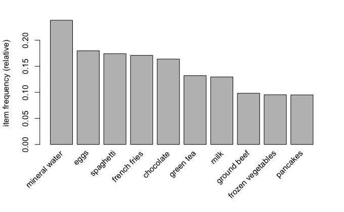

```r
# Visualizing the frequency of products
itemFrequencyPlot(dataset, topN = 10)
```

Here we only consider the product bought by over $3$ times a day, so `support` will be $3\times7\div7500$ which is equal to $0.0028$.

```r
# Training Apriori on the dataset
rules = apriori(data = dataset, parameter = list(support = 0.003, confidence = 0.2))
```

```
Apriori

Parameter specification:
```

|  | confidence | minval | smax | arem | aval | originalSupport | maxtime | support | minlen | maxlen | target | ext |
| --- | --- | --- | --- | --- | --- | --- | --- | --- | --- | --- | --- | --- |
|  | 0.2 | 0.1 | 1 | none | FALSE | TRUE | 5 | 0.003 | 1 | 10 | rules | FALSE |

```
Algorithmic control:
```

|  | filter | tree | heap | memopt | load | sort | verbose |
| --- | --- | --- | --- | --- | --- | --- | --- |
|  | 0.1 | TRUE | TRUE | FALSE | TRUE | 2 | TRUE |

```
Absolute minimum support count: 22

set item appearances ...[0 item(s)] done [0.00s].
set transactions ...[119 item(s), 7501 transaction(s)] done [0.01s].
sorting and recoding items ... [115 item(s)] done [0.00s].
creating transaction tree ... done [0.00s].
checking subsets of size 1 2 3 4 5 done [0.01s].
writing ... [1348 rule(s)] done [0.00s].
creating S4 object  ... done [0.01s].
```

```r
# Visualizing the results
inspect(sort(rules, by = 'lift')[1:10])
```

|  | lhs |  | rhs | support | confidence | lift | count |
| --- | --- | --- | --- | --- | --- | --- | --- |
| [1] | {mineral water,whole wheat pasta} | => | {olive oil} | 0.003866151 | 0.4027778 | 6.115863 | 29 |
| [2] | {frozen vegetables,milk,mineral water} | => | {soup} | 0.003066258 | 0.2771084 | 5.484407 | 23 |
| [3] | {fromage blanc} | => | {honey} | 0.003332889 | 0.2450980 | 5.164271 | 25 |
| [4] | {spaghetti,tomato sauce} | => | {ground beef} | 0.003066258 | 0.4893617 | 4.980600 | 23 |
| [5] | {light cream} | => | {chicken} | 0.004532729 | 0.2905983 | 4.843951 | 34 |
| [6] | {pasta} | => | {escalope} | 0.005865885 | 0.3728814 | 4.700812 | 44 |
| [7] | {french fries,herb & pepper} | => | {ground beef} | 0.003199573 | 0.4615385 | 4.697422 | 24 |
| [8] | {cereals,spaghetti} | => | {ground beef} | 0.003066258 | 0.4600000 | 4.681764 | 23 |
| [9] | {frozen vegetables,mineral water,soup} | => | {milk} | 0.003066258 | 0.6052632 | 4.670863 | 23 |
| [10] | {french fries,ground beef} | => | {herb & pepper} | 0.003199573 | 0.2307692 | 4.665768 | 24 |

## 5.2 Eclat

### 5.2.1 Eclat Intuition

In Eclat model, we only have support:

$$\text{support}(l)=\frac{\text{the number of transactions containing }l}{\text{the number of transactions}}$$

$l$ stands for the set of two or more items.

Overall, the step-by-step process of Eclat algorithm is:

- **STEP 1**: Set a minimum support.
- **STEP 2**: Take all the subsets in transactions having higher support than minimum support.
- **STEP 3**: Sort these subsets by decreasing support.

### 5.2.2 Eclat in R

In `eclat`, we set `minlen = 2` to indicate we need at least $2$ items in each set.

```r
# Training eclat on the dataset
rules = eclat(data = dataset, parameter = list(support = 0.003, minlen = 2))
```

```
Eclat

parameter specification:
```

|  | tidLists | support | minlen | maxlen | target | ext |
| --- | --- | --- | --- | --- | --- | --- |
|  | FALSE | 0.003 | 2 | 10 | frequent itemsets | FALSE |

```
algorithmic control:
```

|  | sparse | sort | verbose |
| --- | --- | --- | --- |
|  | 7 | -2 | TRUE |

```
Absolute minimum support count: 22

create itemset ...
set transactions ...[119 item(s), 7501 transaction(s)] done [0.01s].
sorting and recoding items ... [115 item(s)] done [0.00s].
creating sparse bit matrix ... [115 row(s), 7501 column(s)] done [0.01s].
writing  ... [1328 set(s)] done [0.02s].
Creating S4 object  ... done [0.00s].
```

```r
# Visualizing the results
inspect(sort(rules, by = 'support')[1:10])
```

|  | items | support | count |
| --- | --- | --- | --- |
| [1] | {mineral water,spaghetti} | 0.05972537 | 448 |
| [2] | {chocolate,mineral water} | 0.05265965 | 395 |
| [3] | {eggs,mineral water} | 0.05092654 | 382 |
| [4] | {milk,mineral water} | 0.04799360 | 360 |
| [5] | {ground beef,mineral water} | 0.04092788 | 307 |
| [6] | {ground beef,spaghetti} | 0.03919477 | 294 |
| [7] | {chocolate,spaghetti} | 0.03919477 | 294 |
| [8] | {eggs,spaghetti} | 0.03652846 | 274 |
| [9] | {eggs,french fries} | 0.03639515 | 273 |
| [10] | {frozen vegetables,mineral water} | 0.03572857 | 268 |